# A brief tutorial for estimating cell fate specific GRN using NetID

Weixu Wang, Institute of Computational Biology, Helmholtz Center Munich, Munich, Germany and Dominic Grün, Würzburg Institute of Systems Immunology, Julius‐Maximilians-Universität Würzburg, Würzburg, Germany

2025-01-21

#### Package

NetID 0.1.2

# 1 Introduction

The NetID approach is designed to infer metacells that capture the most significant cell state variations on the manifold while reducing the sample size needed for accurate gene regulatory network (GRN) inference. NetID integrates GENIE3 for GRN inference, but alternative methods can be applied to metacell profiles. However, since each cell lineage is potentially governed by a unique GRN topology, a global GRN model such as GENIE3 may provide insufficient resolution or even confound lineage-specific sub-networks. To overcome this limitation, we utilize cell fate probabilities inferred from pseudotime or RNA velocity to order cells along their respective lineage trajectories. This allows the prediction of directed regulator-target gene relations by ridge regression Granger causality tests. By integrating the GRN inferred from the Granger causal model and GENIE3, we can learn lineage-specific GRNs that enable the identification of important driver genes and regulatory interactions during cell fate decisions.

This document provides a detailed tutorial on how to conduct network inference through NetID on hematopoietic single-cell RNA-seq datasets. First, load the single-cell datasets (The datasets can be downloaded from https://github.com/WWXkenmo/NetID_package/tree/dataset) and the NetID packages.

```r
library(NetID)
sce <- readRDS("blood_sce.rds")
```

The sce object contains the matrices of spliced/unspliced read counts and the metadata of cells. Seurat, SingleCellExperiment, or SCseq (from RaceID3/VarID2) objects can be used as input. Seurat or SingleCellExperiment objects can have as single `RNA` assay or both `spliced` and `unspliced` assays. The latter is required if CellRank should be used for the inference of lineage probabilities (see FateDynamic). If only an `RNA` assay is available, FateDynamic falls back to Palantir. Additionally, we require gene sets for transcription factors to define the regulators.

```r
TF <- read.csv("mouse-tfs.csv",header=TRUE,stringsAsFactors=FALSE)
sce
```

```
## class: SingleCellExperiment
## dim: 10670 4444
## metadata(0):
## assays(2): spliced unspliced
## rownames(10670): Rbfox2 Kif13b ... Mad2l1bp Tufm
## rowData names(0):
## colnames(4444): AATTCAGTATCACCGAG GAACGCCATTGTAATCCC ...
##   ATTTGGGAGATCAAGTG AGTGGATGGCTGTTCTT
## colData names(7): orig.ident nCount_RNA ... seurat_clusters celltype
## reducedDimNames(1): PCA
## mainExpName: NULL
## altExpNames(0):
```

## 1.1 Note

Before running NetID, please check your cell type labels to ensure that all spaces are transformed into underscores.

```r
celltype = as.character(as.matrix(sce$celltype))
transform_to_underscore <- function(input_string) {
  transformed_string <- gsub(" ", "_", tolower(input_string))
  return(transformed_string)
}

# Apply the transformation function to the character sequence
transformed_sequence <- sapply(celltype, transform_to_underscore)
names(transformed_sequence) <- NULL
sce$celltype <- as.factor(transformed_sequence)
```

# 2 Learning GRN skeleton from sketched and aggregated single cell RNA-seq datasets

In the first step, NetID samples the single-cell RNA-seq dataset using sketching methods, such as geosketch or Seurat sketch. These sketching methods sample cells as “meta-cells”, encompassing the entire latent manifold of the single-cell transcriptome. Subsequently, the nearest neighborhoods of these meta-cells are specifically assigned to one meta-cell based on the edges’ P-values calculated from VarID. Finally, aggregation is performed. The resulting Gene Expression Profile (GEP) of the meta-cells serves as the input for network inference methods like GENIE3 (default), enabling the learning of the basic network structure.

```r
dyn.out <- RunNetID(sce, regulators = TF[,1], targets = TF[,1],
                    netID_params = list(normalize=FALSE),
                    dynamicInfer = FALSE,no_cores = 4)
```

```
## Input object is SingleCellExperiment...
## Build VarID object...
## Using NetID to perform skeleton estimation...
## prune sampled neighbourhoods according to q-value...
## assign weight for edges using p-value...
## aggregated matrix: the number of genes:895; the number of samples:461
```

```
## Tree method: RF
## K: sqrt
## Number of trees: 500
```

[output not shown]

```
## Done...
```

Upon executing the aforementioned function, a `VarID` object will be saved in the local directory. Subsequently, each time RunNetID is initiated, it will verify if a `varID_res.rds` file exists in the local directory and automatically load it. This streamlines the process, relieving the user from the need to rerun VarID. Please delete the object from local directory, if you would like to create a new `VarID` from the same or from another dataset in the same directory. Should a user wish to specify a custom save path, they have the option to manually set the parameter as follows

```r
dyn.out <- RunNetID(sce, regulators = TF[,1], targets = TF[,1],
                    netID_params = list(normalize=FALSE),
                    dynamicInfer = FALSE, work_dir = "Set/the/Path/")
```

To review the details of the RunNetID parameters, one could use…

```r
?check_netID_params()
```

By default, NetID uses random sampling. However, we strongly encourage users to utilize geosketch sampling. Geosketch sampling requires users to install the geosketch Python module first. For more installation details, please visit https://github.com/brianhie/geosketch .

```r
# install python "geosketch"
dyn.out <- RunNetID(sce, regulators = TF[,1], targets = TF[,1],
                    netID_params = list(sketch.method = "geosketch",
                                        normalize=FALSE),
                    dynamicInfer = FALSE)
```

```
## Input object is SingleCellExperiment...
## Find VarID object at local dictionary, Read VarID object...
## Using NetID to perform skeleton estimation...
## prune sampled neighbourhoods according to q-value...
## assign weight for edges using p-value...
## aggregated matrix: the number of genes:895; the number of samples:387
## Done...
```

The computed global GRN is saved in `dyn.out$skeleton`.

```r
names(dyn.out)
```

[output not shown]

# 3 Perform pruning on Shared Nearest-neighbor (SNN) graph

NetID also accepts a Seurat object as input and utilizes the SNN graph for pruning and aggregation. Compared to the raw KNN graph, the SNN graph can provide a clearer neighbor graph. To begin, we first construct the Seurat object. This dataset includes both spliced and unspliced readouts; for building the GRN, we used the spliced readout. Users can also specify the gene read count layer they wish to use for constructing the GRN.

```r
library(SummarizedExperiment)
library(Seurat)
Se <- CreateSeuratObject(counts = assays(sce)$spliced)

Se <- NormalizeData(Se, normalization.method = "LogNormalize",
                    scale.factor = 10000)
Se <- FindVariableFeatures(Se, selection.method = "vst",
                           nfeatures = 1000)

all.genes <- rownames(Se)
Se <- ScaleData(Se, features = all.genes)
Se <- RunPCA(Se, features = VariableFeatures(object = Se))
Se <- FindNeighbors(Se, dims = 1:10)
Se <- FindClusters(Se, resolution = 0.5)
```

```
## Modularity Optimizer version 1.3.0 by Ludo Waltman and Nees Jan van Eck
##
## Number of nodes: 4444
## Number of edges: 147926
##
## Running Louvain algorithm...
## Maximum modularity in 10 random starts: 0.9024
## Number of communities: 12
## Elapsed time: 0 seconds
```

```r
Se@meta.data$celltype <- celltype
## or use 'seurat_clusters' as cluster_label in FateDynamic
```

Then, run NetID as follows and set `SNN` = TRUE.

```r
dyn.out <- RunNetID(Se, regulators = TF[,1], targets = TF[,1],
                    netID_params = list(normalize=FALSE, SNN = TRUE),
                    dynamicInfer = FALSE)
```

```
## Input object is Seurat...
## Find VarID object at local dictionary, Read VarID object...
## Using NetID to perform skeleton estimation...
## prune sampled neighbourhoods according to q-value...
## assign weight for edges using p-value...
## aggregated matrix: the number of genes:895; the number of samples:450
## Done...
```

If you would like to continue the tutorial with the Seurat object, overwrite the input.

```r
sce <- Se
```

# 4 Inferring Fate Probability and base GRN

The previous steps only output the global GRN learned from all sampled meta-cells. To learn lineage-specific GRNs, we need to first run `CellRank` and/or `Palantir`. NetID provides a function for end-to-end cell fate analysis using `CellRank` and/or `Palantir`. If an SCseq object is used, the cpart slot has to contain a cluster partition (generated by RaceID3/VarID2 clustering routines or manually). In this case, `cpart` is always used as `cluster_label`. For Seurat or SingleCellExperiment input objects, the user can provide a celltype annotation as `cluster_label`, wich has to be stored in a `colData` or `meta.data` slot, respectively. One could also just assign a cluster partition, e.g., `seurat_clusters`. Please also see Note (above).

```r
FateDynamic(sce,
            global_params = list(cluster_label = "celltype",
                                 min_counts = 10 ,
                                 nhvgs = 3000,
                                 velo = FALSE),
            palantir_params = list(start_cell = "TGATACGTGCTAGGAGCTT"))
```

```
## Using palantir to perform cell fate analysis...
```

To review the details of global parameters, Palantir parameters and CellRank parameters in FateDynamic function, one could use

```r
?check_global_params
?check_palantir_params
?check_cellrank_params
```

NetID offers three methods for identifying the root cell, which include the stemness score-based methods, `SCENT` and `CytoTRACE`, as well as using marker genes (`markergene`). In the tutorial, the cell with ID “TGATACGTGCTAGGAGCTT” is set as the root cell. Users also have the option to manually set the desired root cell.

If a user wishes to unsupervisedly identify the root cell, they can execute the following command:

```r
FateDynamic(sce,
            global_params = list(cluster_label = "celltype",
                                 min_counts = 10 ,
                                 nhvgs = 3000,
                                 velo = FALSE),
            palantir_params = list(method = "scent"))
```

Users also have the option to define the terminal states if they possess prior knowledge.

```r
FateDynamic(sce,
            global_params = list(cluster_label = "celltype",
                                 min_counts = 10 ,
                                 nhvgs = 3000,
                                 velo = FALSE),
            palantir_params =
              list(start_cell = "TGATACGTGCTAGGAGCTT",
                   terminal_state = c("erythroblasts_stage2",
                                      "neutrophils")))
```

```
## Using palantir to perform cell fate analysis...
```

To compute lineage-specific GRNs, proceed to run NetID once more, considering the availability of dynamic information with dynamicInfer = TRUE.

```r
dyn.out <- RunNetID(sce,
                    regulators = TF[,1],
                    targets = TF[,1],
                    netID_params =
                    list(normalize=FALSE,
                         sketch.method = "geosketch"),
                    dynamicInfer = TRUE,
                    velo=FALSE)
```

```
## Input object is SingleCellExperiment...
## Find VarID object at local dictionary, Read VarID object...
## Using NetID to perform skeleton estimation...
## prune sampled neighbourhoods according to q-value...
## assign weight for edges using p-value...
## aggregated matrix: the number of genes:897; the number of samples:361
## Classify lineage for palantir fate prob...
##                          cluster1  cluster2  cluster3  cluster4  cluster5
## neutrophils          4.137327e+02 0.8718961 0.8923043 0.5377461  0.049859
## erythroblasts_stage2 2.417019e-03 1.1469257 1.1206939 1.8596135 20.056559
## Allow shared cell state between different lineage...
## Done...
```

We note that the `FateDynamic` function provides a preliminary estimation of cell fate probabilities. However, accurate cell fate estimation relies on further refinements and the incorporation of prior information. If users wish to use their own cell fate probability matrix (`fate_prob`), they can directly plug in these values to update the `dyn.out` object using the `LineageClassifier` function.

`fate_prob` is a cell fate probability matrix with cells as rows, columns as cell fates; values are the probabilities of each cell being assigned to each fate. This cell fate probability matrix can be inferred via `cellrank`, `palantir`, or any other method, e.g., `FateID`.

```r
head(fate_prob)
```

```
##                     neutrophils erythroblasts_stage2
## AATTCAGTATCACCGAG             0            0.9998237
## GAACGCCATTGTAATCCC            0            0.9998298
## ACCGCAACTTAGTCGCA             0            0.9998303
## GATCTGTGGTCCACATTA            0            0.9998183
## GTCTCTCTGGAAACAG              0            0.9998115
## TGATACGTGCTTCTCACTT           0            0.9997995
```

Then, cells are assigned to specific cell fates based on `fate_prob` using the `LineageClassifier` function, and plugged into the object `dyn.out`, along with `fate_prob`. The whole procedure is shown below:

```r
## Run NetID
dyn.out <- RunNetID(sce,
                    regulators = TF[,1],
                    targets = TF[,1],
                    netID_params =
                    list(normalize=FALSE,
                         sketch.method = "geosketch"),
                    dynamicInfer = FALSE,
                    velo=FALSE)

## Inject dynamic information
dyn.out$LineageClass <- LineageClassifier(fate_prob, maxState = 10, cut_off = 0)
dyn.out$fate_prob <- fate_prob # cell fate probability matrix
```

These steps can be used to skip the `FateDynamic` step. and the output can directly be used for the next step (`FateCausal`).

NetID classifies the cells based on the fate probability matrix using a Gaussian Mixture Model. Next, we compute the lineage fate probability fold change to assign each cluster to a specific lineage. To visualize the cell fate probability in a PCA 2D space, the following function can be utilized:

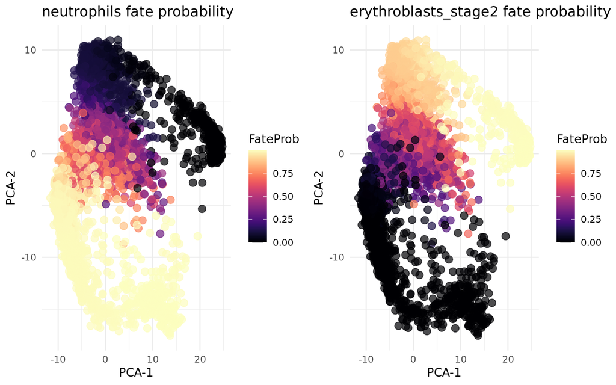

```r
## load basis information
dyn.out$basis <- reducedDim(sce, "PCA")[,c(1,2)]

## For SCseq, e.g.
## dyn.out$basis <- sce@umap

## For Seurat, e.g.
## dyn.out$basis <- Se@reductions$umap_spliced@cell.embeddings

library(cowplot)
p1 = plotFateProb(dyn.out,basis=dyn.out$basis,basis_name = "PCA",
                  lineage = colnames(dyn.out$fate_prob)[1])
p2 = plotFateProb(dyn.out,basis=dyn.out$basis,basis_name = "PCA",
                  lineage = colnames(dyn.out$fate_prob)[2])
plot_grid(p1,p2)
```

# 5 Learning cell fate specific GRN through Granger causal regression model

The dyn.out object contains the skeleton of the global network (learned from all cells without lineage information) and cell fate probability information. NetID would run an L2-penalized Granger regression model for each target gene to re-calculate the regulatory coefficients of the skeleton, with using cell fate probability to define the “time-series”, and then aggregates the learned coefficients with the global coefficients through a rank-based method.

```r
GRN <- FateCausal(dyn.out,L=30)
```

```
## Inferring GRN on Lineage 1,ncells = 335 ,readout = Gene Expression..
## Inferring GRN on Lineage 2,ncells = 199 ,readout = Gene Expression..
## Integrating Network Skeleton And Granger Causal Coefficient...
```

The output of FateCausal is a list object that contains the lineage-specific Gene Regulatory Network (GRN). In this context, `grn` represents the weighted unsigned network, while `sign_grn` represents the weighted signed network.

```r
GRN$grn[[1]][1:10,1:10]
```

```
##        Abl1 Abt1        Aebp2          Aes         Aff4        Agap3 Ahctf1 Ahr
## Aatf      0    0 1.770688e-08 0.000000e+00 0.000000e+00 6.527005e-10      0   0
## Abl1      0    0 0.000000e+00 0.000000e+00 0.000000e+00 1.129788e-09      0   0
## Abt1      0    0 0.000000e+00 0.000000e+00 0.000000e+00 0.000000e+00      0   0
## Aebp2     0    0 0.000000e+00 0.000000e+00 0.000000e+00 0.000000e+00      0   0
## Aes       0    0 0.000000e+00 0.000000e+00 0.000000e+00 0.000000e+00      0   0
## Aff4      0    0 0.000000e+00 0.000000e+00 0.000000e+00 0.000000e+00      0   0
## Agap3     0    0 0.000000e+00 0.000000e+00 0.000000e+00 0.000000e+00      0   0
## Ahctf1    0    0 0.000000e+00 0.000000e+00 0.000000e+00 0.000000e+00      0   0
## Ahr       0    0 9.258331e-10 0.000000e+00 7.302628e-10 0.000000e+00      0   0
## Aip       0    0 0.000000e+00 1.567232e-07 0.000000e+00 0.000000e+00      0   0
##                 Aip         Akt1
## Aatf   0.000000e+00 0.000000e+00
## Abl1   0.000000e+00 0.000000e+00
## Abt1   0.000000e+00 0.000000e+00
## Aebp2  0.000000e+00 0.000000e+00
## Aes    0.000000e+00 3.152624e-07
## Aff4   0.000000e+00 0.000000e+00
## Agap3  0.000000e+00 0.000000e+00
## Ahctf1 0.000000e+00 0.000000e+00
## Ahr    1.303853e-09 0.000000e+00
## Aip    0.000000e+00 0.000000e+00
```

Rows represent targets, and columns represent regulators

# 6 Module Identification and Visualization

Utilize the `ModuleFinder()` function to identify the nearest module for a specific Transcription Factor (TF) within the gene regulatory network. Input the TF of interest into the function. This function also provides the option to conduct statistical tests to evaluate the significance of the identified module. To illustrate its usage, we begin by identifying the Gata1-related module within the Erythroblasts (Ery) lineage.

```r
result = ModuleFinder(GRN,"erythroblasts_stage2",c("Gata1"),
                      method = "spinglass")
```

```
## Using signed network, the regulation type is determined by granger regression model
## targets and regulators not the same
## Modularity values=
##        Gata1
## 0.0006068268
## Starting Monte Carlo Runs
## Done for seed/module Gata1
```

```r
result
```

```
## $ModuleList
## $ModuleList$Gata1
##  [1] "Gata1"  "Ahctf1" "Bcl11a" "Btaf1"  "E2f4"   "Ell2"   "Epor"   "Erf"
##  [9] "Cbx3"   "Fubp3"  "Gfi1b"  "Gtf2h3" "Hdac7"  "Hdgf"   "Hmgxb3" "Klf1"
## [17] "Klf16"  "Klf3"   "Ldb1"   "Mbd2"   "Mllt3"  "Myef2"  "Nfia"   "Nfix"
## [25] "Nrip1"  "Orc2"   "Pax9"   "Pbx4"   "Phf10"  "Polr3d" "Rfx2"   "Ring1"
## [33] "Sox6"   "Sp4"    "Ssbp2"  "Ssbp3"  "Tal1"   "Tcf3"   "Tfcp2"  "Upf1"
## [41] "Zbtb32" "Ikzf1"  "Mapk9"  "Rnps1"  "Trim24" "Pcgf6"  "Rnf19a" "Ubp1"
## [49] "Taf12"
##
##
## $ModuleTestResult
##          TF Module_size ModularityScore P_value
## Gata1 Gata1          49    0.0006068268       0
```

Upon examining the ModuleFinder output, we retrieve the identified Gata1-related module along with its corresponding statistical test results. Notably, in the Erythroid branch, we successfully identified the Gata1-related regulatory module. To compare, we can ascertain whether a Gata1-related module can be recovered for the Neutrophils (Neu) branch.

```r
result2 = ModuleFinder(GRN,"neutrophils",c("Gata1"),
                       method = "spinglass")
```

```
## Using signed network, the regulation type is determined by granger regression model
## targets and regulators not the same
## Modularity values=
##        Gata1
## 0.0004268729
## Starting Monte Carlo Runs
## Done for seed/module Gata1
```

```r
result2
```

```
## $ModuleList
## $ModuleList$Gata1
##  [1] "Gata1"  "Ahctf1" "Bcl11a" "Btaf1"  "E2f4"   "Ell2"   "Epor"   "Asb1"
##  [9] "Cbx3"   "Gfi1b"  "Gtf2h3" "Hdac7"  "Hdgf"   "Hif3a"  "Hmgxb3" "Klf1"
## [17] "Klf16"  "Klf3"   "Ldb1"   "Mbd2"   "Mllt3"  "Myef2"  "Nfia"   "Nfix"
## [25] "Nrip1"  "Orc2"   "Pawr"   "Pax9"   "Pbx4"   "Phf10"  "Polr3d" "Rfx2"
## [33] "Satb1"  "Sox6"   "Sp4"    "Ssbp2"  "Ssbp3"  "Tal1"   "Tcf3"   "Upf1"
## [41] "Ikzf1"  "Mapk9"  "Sox5"   "Taf12"  "Trim24" "Brpf3"  "Zbtb32" "Rnps1"
##
##
## $ModuleTestResult
##          TF Module_size ModularityScore P_value
## Gata1 Gata1          48    0.0004268729       0
```

Additionally, should we desire to discover smaller modules, it is possible to adjust the `gamma` parameter within the `ModuleFinder` function.

```r
result = ModuleFinder(GRN,"erythroblasts_stage2",c("Gata1"),
                      method = "spinglass",gamma = 0.4)
```

```
## Using signed network, the regulation type is determined by granger regression model
## targets and regulators not the same
## Modularity values=
##        Gata1
## 0.0006301316
## Starting Monte Carlo Runs
## Done for seed/module Gata1
```

```r
result
```

```
## $ModuleList
## $ModuleList$Gata1
##  [1] "Gata1"  "Ahctf1" "Bcl11a" "Btaf1"  "E2f4"   "Ell2"   "Epor"   "Gfi1b"
##  [9] "Gtf2h3" "Hdac7"  "Hmgxb3" "Klf1"   "Klf16"  "Klf3"   "Ldb1"   "Mbd2"
## [17] "Mllt3"  "Myef2"  "Nfia"   "Nfix"   "Nrip1"  "Orc2"   "Phf10"  "Polr3d"
## [25] "Rfx2"   "Sox6"   "Sp4"    "Ssbp2"  "Ssbp3"  "Tal1"   "Tcf3"   "Tfcp2"
## [33] "Upf1"   "Zbtb32" "Ikzf1"  "Rnps1"  "Trim24" "Mapk9"  "Ubp1"   "Pcgf6"
##
##
## $ModuleTestResult
##          TF Module_size ModularityScore P_value
## Gata1 Gata1          40    0.0006301316       0
```

`gamma` serves as a parameter in the spinglass algorithm, allowing control over the size of the module.

For network visualization, NetID also offers a function designed to assist in visualizing the identified modules.

```
## targets and regulators not the same
```

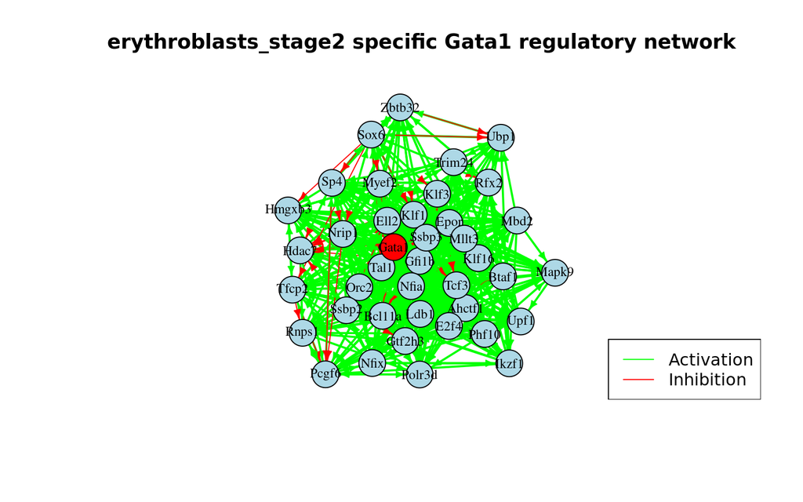

```r
graphPlot(GRN,result,"Gata1","erythroblasts_stage2")
```